# Graphics Solutions

bioX

07/15/2020

## Load data

```r
library("parathyroidSE")
library("EnsDb.Hsapiens.v86")
library("dplyr")
library("ggplot2")

data("parathyroidGenesSE", package = "parathyroidSE")

genes <- read.csv(textConnection(
  "name, group
   ESR1,  estrogen
   ESR2,  estrogen
   CASR,  parathyroid
   VDR,   parathyroid
   JUN,   parathyroid
   CALR,  parathyroid
   ORAI2, parathyroid"),
  stringsAsFactors = FALSE, strip.white = TRUE)

ens <- ensembldb::select(EnsDb.Hsapiens.v86,
  keys = list(GenenameFilter(genes$name),
              TxBiotypeFilter("protein_coding")),
  columns = c("GENEID", "GENENAME"))
ens <-
  dplyr::filter(ens, GENEID %in% rownames(parathyroidGenesSE)) %>%
  mutate(group = genes$group[match(GENENAME, genes$name)])


countData <- assay( parathyroidGenesSE )
gene.counts <- t(countData[ens$GENEID, ])
colnames(gene.counts) <- ens$GENENAME
dat <- cbind(data.frame(colData( parathyroidGenesSE)), data.frame(gene.counts))
head(dat)
```

```
##         run experiment patient treatment time submission     study    sample
## 1 SRR479052  SRX140503       1   Control  24h  SRA051611 SRP012167 SRS308865
## 2 SRR479053  SRX140504       1   Control  48h  SRA051611 SRP012167 SRS308866
## 3 SRR479054  SRX140505       1       DPN  24h  SRA051611 SRP012167 SRS308867
## 4 SRR479055  SRX140506       1       DPN  48h  SRA051611 SRP012167 SRS308868
## 5 SRR479056  SRX140507       1       OHT  24h  SRA051611 SRP012167 SRS308869
## 6 SRR479057  SRX140508       1       OHT  48h  SRA051611 SRP012167 SRS308870
##   CALR  CASR ESR1 ESR2  JUN ORAI2  VDR
## 1 5055 14525    2    1 1799   632 1167
## 2 6161 16870    3    3 1153  1424 1653
## 3 3333  7798    1    1 1086   309  688
## 4 6407 14299    2    1 1227   974 1407
## 5 3810  9235    4    1 1258   326  702
## 6 4885 12994    2    3  906   814 1235
```

## Initial plot

Plot one of the estrogen related gene's counts (ESR1) with plot aesthetics and faceting to separate patients, treatments and times.

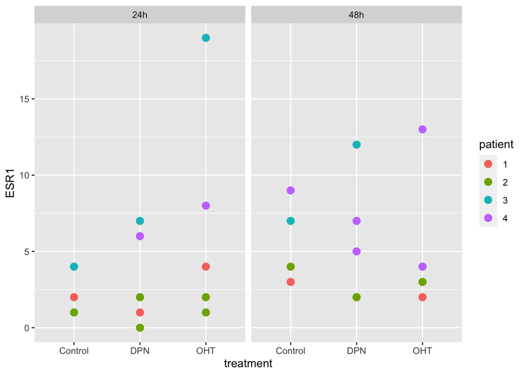

```r
ggplot(dat, aes(col = patient, x = treatment, y = ESR1)) +
  geom_point(size = 3) +
  facet_grid( . ~ time)
```

## Quiz Answers

From the plot of the parathyroid data, answer the following.

**Quiz question 1** : How many patients are there?

**Answer:** There are four patients.

**Quiz question 2** : How many time points are there?

**Answer:** There are two timepoints (24h, 48h).

**Quiz question 3** : There were 3 treatments: "Control", "DPN", and "OHT". How many measurements were taken from patient 2 under the DPN treatment?

**Answer:** There were three measurements taken for patient 2 (green) under DPN treament.

**Question**: Make your own plot of VDR versus CASR. (That is CASR, not CALR).

**Answer**:

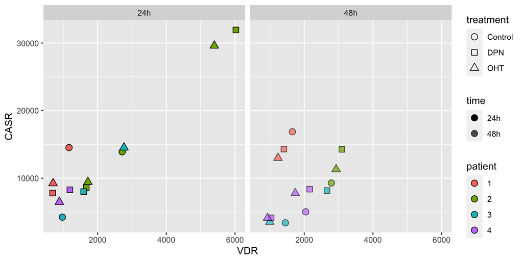

```r
ggplot(dat, aes( x = VDR, y = CASR)) +
    geom_point(aes(fill = patient, shape = treatment, alpha=time), size = 3) +
    scale_alpha_manual(values = c(1.0, 0.7)) +
    scale_shape_manual(values = c(21, 22, 24)) +
    guides(fill = guide_legend(override.aes=list(shape=21))) +
    facet_grid( . ~ time)
```

**Quiz question 4** : Which patient has the highest recorded level of CASR?

**Answer:** Patient 2.

**Quiz question 5** : Which of the following pairs of patients seem to be well separated in this plot (i.e., for which two patients you can draw a line on the plot that perfectly separates them)?

**Answer:** Patient 1 and patient 2, also Patient 1 and patient 3.

**Quiz question 6** : You need to know which pairs of patients are well separated with respect to the genes VDR and CASR (i.e., you can draw a line on the plot that perfectly separates the patients). Which of the following methods can help you visualize this?

**Answer:** Plot VDR versus CASR, and change the shape of the point according to the patient. Plot VDR versus CASR, and color the points according to the patient.

**Quiz question 7** : Which patient looks different from the other three when you plot VDR versus ORAI2?

**Answer:** Patient 2.

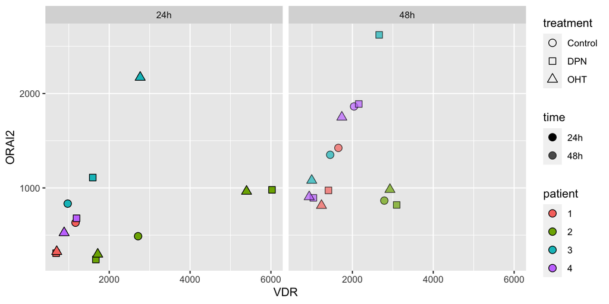

```r
ggplot(dat, aes( x = VDR, y = ORAI2)) +
    geom_point(aes(fill = patient, shape = treatment, alpha=time), size = 3) +
    scale_alpha_manual(values = c(1.0, 0.7)) +
    scale_shape_manual(values = c(21, 22, 24)) +
    guides(fill = guide_legend(override.aes=list(shape=21))) +
    facet_grid( . ~ time)
```

**Quiz question 8** : Plot ORAI2 versus JUN. Which can you separate best?

**Answer:** 24 hours vs. 48 hours.

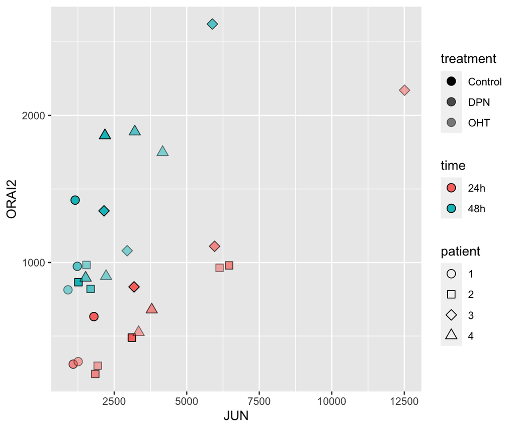

```r
ggplot(dat, aes( x = JUN, y = ORAI2)) +
    geom_point(aes(fill = time, shape = patient, alpha=treatment), size = 3) +
    scale_alpha_manual(values = c(1.0, 0.7, 0.5)) +
    scale_shape_manual(values = c(21, 22, 23,24)) +
    guides(fill = guide_legend(override.aes=list(shape=21)))
```

**Quiz question 9** : Plot CASR versus (ESR1 + ESR2). Fit a separate linear model for each treatment (Control, DPN, OHT). Which linear models are increasing?

**Answer:** DPN and OHT.

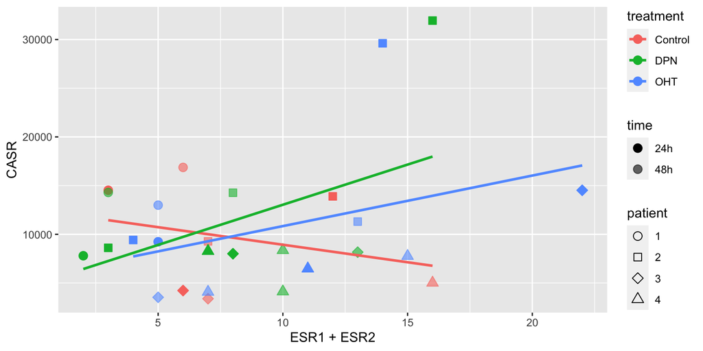

```r
ggplot(dat, aes( y = CASR, x = ESR1 + ESR2)) +
    geom_point(aes(fill = treatment, color=treatment, shape = patient, alpha=time), size = 3) +
    geom_smooth(aes(color = treatment), method = "lm", se=FALSE)+
    scale_alpha_manual(values = c(1.0, 0.6)) +
    scale_shape_manual(values = c(21, 22, 23,24)) +
    guides(fill = guide_legend(override.aes=list(shape=21)))
```

**Quiz question 10** : What is the maximum number of shapes that you are allowed to use in ggplot2 by default?

**Answer:** 6.

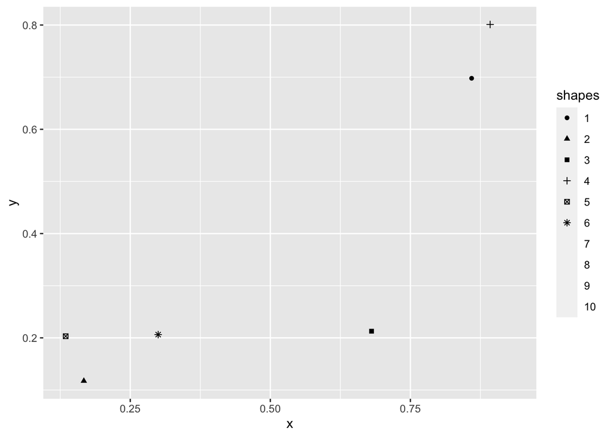

```r
df_shape <- data.frame(x=runif(10),y=runif(10), shapes=as.factor(1:10))
ggplot(df_shape, aes(x=x,y=y, shape=shapes)) + geom_point()
```

**Quiz question 11** : Write the name of the function that you could use to make more than the maximum number of default shapes allowed. Hint: this function has "values" as one of the arguments ____(..., values = (...)).

**Answer:** `scale_shape_manual`.

**Quiz question 12** : What do Themes do in ggplot2?

**Answer:** They control non-data components of the plot.